# ECE 5470 Lab 9 Report

## by Junjie Tian

```python
from v4 import vd
import torch
import torch.nn as nn
```

## A.1 running the tutorial models

#### Model convnet1

Strategy: I will change the number of epochs in training, and try to plot the plot of average DICE score with different threshold values under this number of epoch. Thus, I could find the best threshold for each given number of epochs.

When number of epochs is 15, the loss decreases very slowly after number of epochs = 5, so I think further increase the number of epochs won't be useful. I tried 18 epochs, and the result is worse than 15. Thus I try to decrease the number of epochs.

Number of epochs, threshold, average DICE score

18, 0.0175, 0.257

14, 0.02, 0.259

13, 0.022, 0.0914

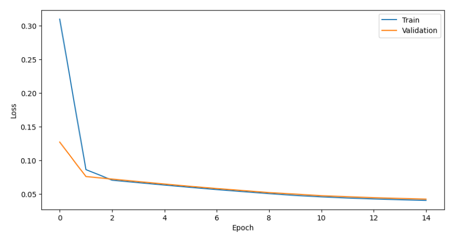

```
Training curve
<scaled size: (448 x 855) >
```

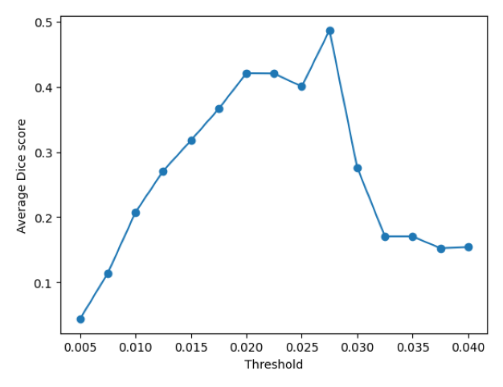

```
Average DICE score v.s. threshold
<scaled size: (432 x 567) >
```

```python
# Display the results of model convnet1
vd.dispmvx("convnet1_15_train.png", size=1.5, capt="Training curve")
vd.dispmvx("convnet1_15_th.png", size=1.5, capt="Average DICE score v.s. threshold")
```

#### Model unet1

I will use similar strategy as previous model.

When the number of epochs is 15, the training loss decreases very slowly when the epoch number is greater than 5. However, the validation loss fluctuates when validation loss is around 10. Thus, there might be over-fitting issues.

I first increase the number of epochs to 18 to confirm my judgment. As I expected, the validation loss curve fluctuates when the epoch number is higher than 15. The maximum average DICE score is lower then when the epoch number is 15. Thus, we try to decrease the number of epochs.

Conclusion: the average DICE score is highest when the number of epochs is 13 and threshold is 0.375.

Number of epochs, threshold, average DICE score

15, 0.02, 0.813

18, 0.9, 0.736

14, 0.3, 0.839

13, 0.375, 0.916

12, 0.25, 0.890

10, 0.25, 0.872

8, 0.06, 0.725

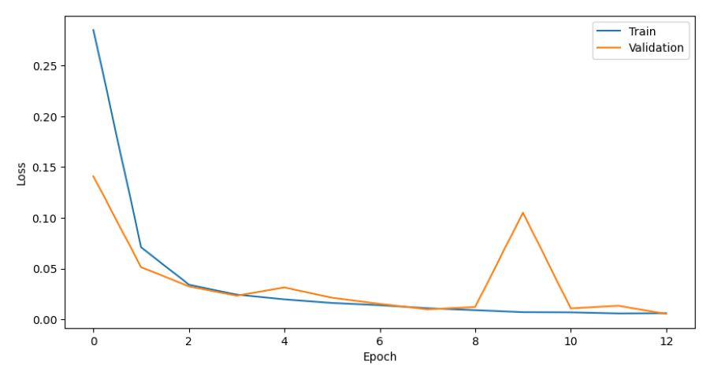

```
Training curve
<scaled size: (448 x 855) >
```

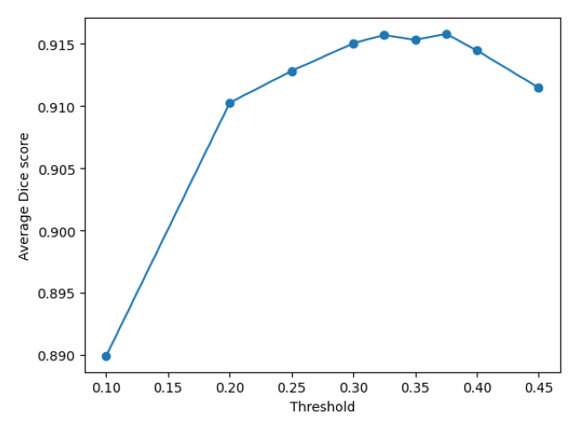

```
Average DICE score v.s. threshold
<scaled size: (432 x 584) >
```

```python
# Display the results of model unet1
vd.dispmvx("unet1_13_train.png", size=1.5, capt="Training curve")
vd.dispmvx("unet1_13_th.png", size=1.5, capt="Average DICE score v.s. threshold")
```

#### Model unet2

I will use similar strategy as previous model.

When the number of epochs is 15, the loss curve decreases very slowly after epoch number is 4. Thus, there might be over-fitting problem. I will first try epoch number = 18 to verify my judgment.

Then I try to decrease the number of epochs. Conclusion: the average DICE score is highest when the number of epochs is 13 and threshold is 0.225.

Number of epochs, threshold, average DICE score

15, 0.175, 0.957

18, 0.2, 0.941

10, 0.375, 0.923

12, 0.225, 0.961

13, 0.225, 0.963

14, 0.325, 0.947

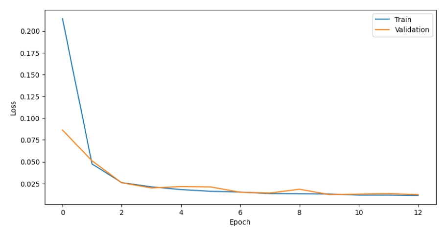

```
Training curve
<scaled size: (448 x 863) >
```

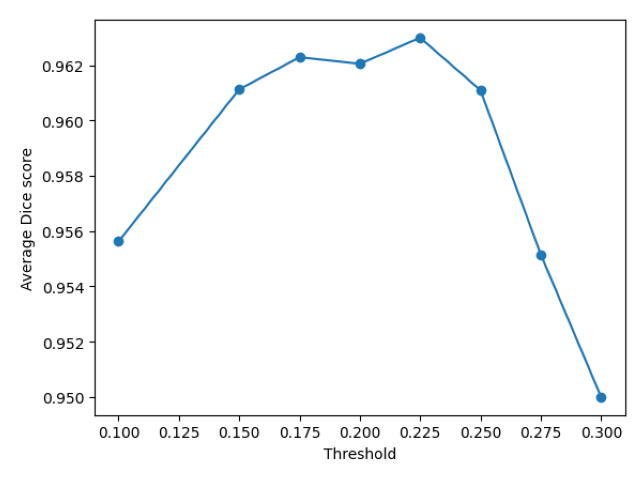

```
Average DICE score v.s. threshold
<scaled size: (432 x 584) >
```

```python
# Display the results of model unet2
vd.dispmvx("unet2_13_train.png", size=1.5, capt="Training curve")
vd.dispmvx("unet2_13_th.png", size=1.5, capt="Average DICE score v.s. threshold")
```

## A.2 Dice training

General method: I first calculate the pos_weight using the code in the first cell under the title 'Main' in 'lab9unet.ipynb'. The pos_weight is about 1.0603. Then I run the two models, convnet1 and unet2, with the modified loss function.

##### A. Dice Training

Therefore, considering the positive weight factor in the loss function may or may not enhance the average dice score of a model. It works for some model, but this method cannot enhance the average dice score for all models in general.

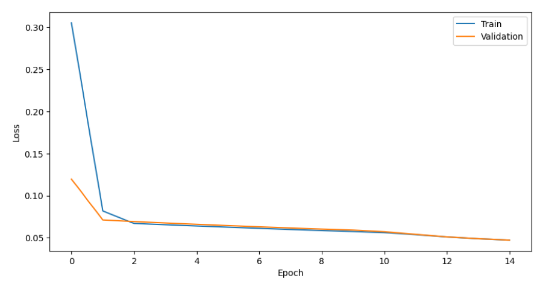

```
Training curve
<scaled size: (448 x 855) >
```

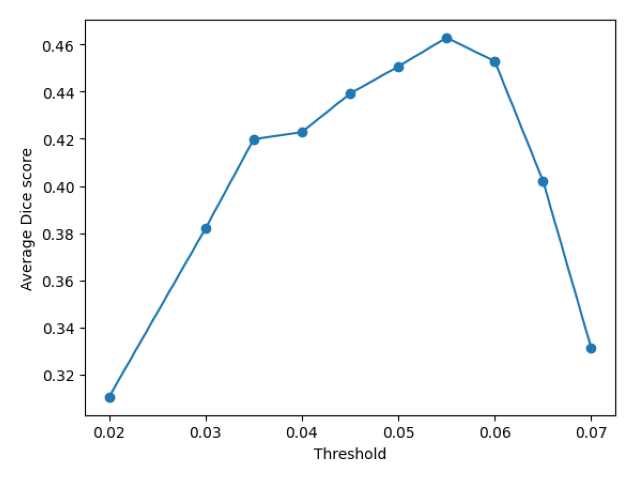

```
Average DICE score v.s. threshold
<scaled size: (432 x 576) >
```

```python
# Display the results of model convnet1 with pos_weight
vd.dispmvx("convnet1_A2_1_train.png", size=1.5, capt="Training curve")
vd.dispmvx("convnet1_A2_1_th.png", size=1.5, capt="Average DICE score v.s. threshold")
```

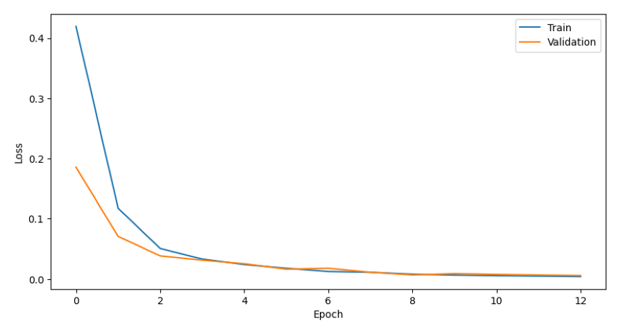

```
Training curve
<scaled size: (448 x 846) >
```

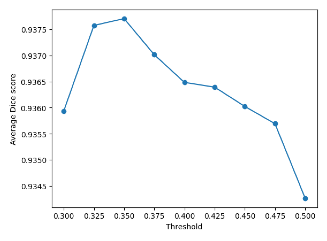

```
Average DICE score v.s. threshold
<scaled size: (432 x 593) >
```

```python
# Display the results of model unet2 with pos_weight
vd.dispmvx("unet2_A2_1_train.png", size=1.5, capt="Training curve")
vd.dispmvx("unet2_A2_1_th.png", size=1.5, capt="Average DICE score v.s. threshold")
```

##### B. Dice training and balancing

In this section, I decide to change the loss function to DiceLoss(). I will train the two models, convnet1 and unet2, with parameters that produced the best result in section A.1 with this different loss function.

For the convnet1 model, when the number of epochs is 15 and threshold is 0.15, the average dice score is about 0.618, which is higher than the original model. This average dice score is also higher than the previous model considering the positive weight factor in the loss function.

For the unet2 model, when the number of epochs is 13 and threshold is 0.05, the average dice score is about 0.962, which is similar to the original model. This average dice score is higher than the previous model considering the positive weight factor in the loss function.

In conclusion, changing the loss function to DiceLoss usually gives similar or better result than the original model and usually gives a better result than the method in part 1 of A.2.

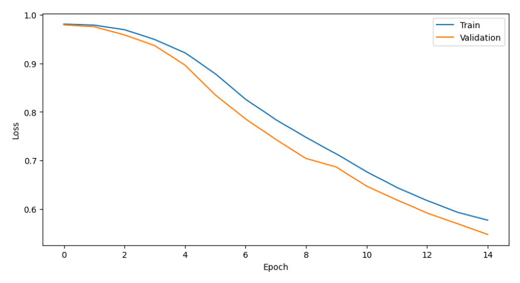

```
Training curve
<scaled size: (451 x 846) >
```

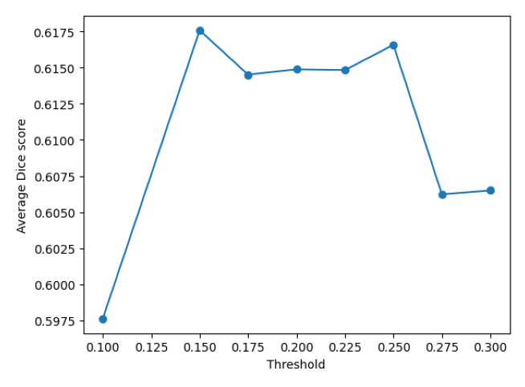

```
Average DICE score v.s. threshold
<scaled size: (432 x 593) >
```

```python
# Display the results of model convnet1 with DiceLoss
vd.dispmvx("convnet1_A2_2_train.png", size=1.5, capt="Training curve")
vd.dispmvx("convnet1_A2_2_th.png", size=1.5, capt="Average DICE score v.s. threshold")

# Remark: Although the loss curve will keep decreasing when I further increase the number of epochs, I don't do it in order to compare the training effectiveness of
# different loss functions in a fair way. Thus, I keep the number of epochs to be 15 here.
```

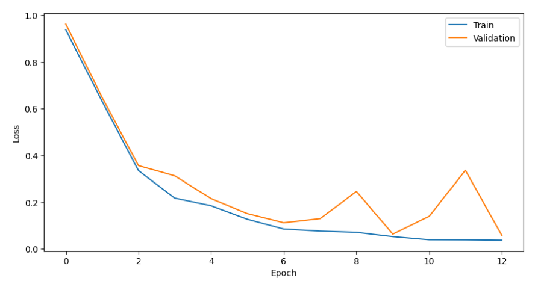

```
Training curve
<scaled size: (450 x 846) >
```

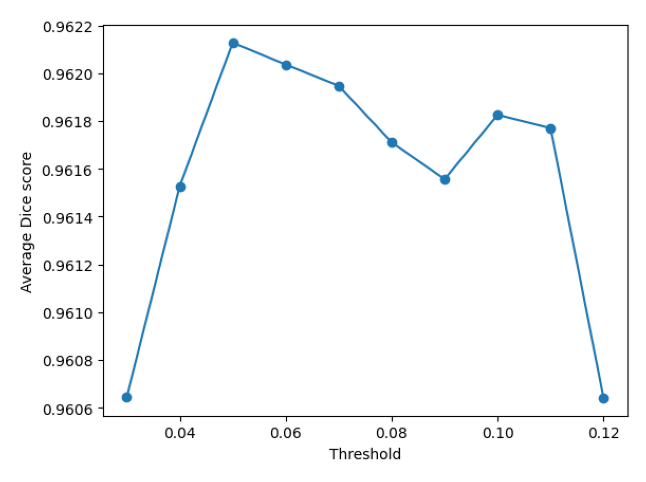

```
Average DICE score v.s. threshold
<scaled size: (437 x 593) >
```

```python
# Display the results of model unet2 with DiceLoss
vd.dispmvx("unet2_A2_2_train.png", size=1.5, capt="Training curve")
vd.dispmvx("unet2_A2_2_th.png", size=1.5, capt="Average DICE score v.s. threshold")
```

## A.3. New Model Design

Modify the tutorial pytorch models to achieve better results.

```python
# Modified models of convnet1 and unet2 for part A.3
class convnet1_modified(nn.Module):
    def __init__(self, in_ch=3, n_channels=8):
        super(convnet1_modified, self).__init__()
        self.activation = F.relu

        self.conv1 = nn.Conv2d(in_ch, n_channels, kernel_size= 3, padding=1)
        self.conv2 = nn.Conv2d(n_channels, 1, kernel_size= 3, padding=1)

    def forward(self, x):
        out = self.conv1(x)
        out = self.activation(out)
        out = self.conv2(out)

        return out

class unet2_modified(nn.Module):
    def __init__(self, in_ch=3, n_channels=8):
        super(unet2_modified, self).__init__()

        self.down1 = down_block(in_ch, n_channels)
        self.down2 = down_block(in_ch=n_channels, out_ch=n_channels*2)

        self.bridge= down_block(in_ch=n_channels*2, out_ch=n_channels*4, max_pooling=False)

        self.up1 = up_block(in_ch=n_channels*4, out_ch=n_channels*2)
        self.up2 = up_block(in_ch=n_channels*2, out_ch=n_channels)
        self.final_conv = nn.Conv2d(n_channels, 1, kernel_size= 3, padding=1)

    def forward(self, x):
        out, skip1 = self.down1(x)
        out, skip2 = self.down2(out)

        out, _ = self.bridge(out)

        out = self.up1(out, skip2)
        out = self.up2(out, skip1)
        out = self.final_conv(out)

        return out
```

For both models, I will use the same number of epochs and loss function as in part A.1 to do a fair comparison. I changed the kernel size of convolutional layers to 3*3 and changed the padding to 1.

##### 1. convnet1 with 3x3

The optimal average dice score occurs when the number of epochs is 15 and the threshold is 0.0225. The average dice score is about 0.163.

##### 2. unet2 with 3x3

The optimal average dice score occurs when the number of epochs is 13 and the threshold is 0.275. The average dice score is about 0.871.

For both models, the average dice score is lower when the kernel size of the convolutional layer is increased to 3*3. Here are some possible reasons:

1. Over-fitting: as the complexity of the model becomes higher by increasing the kernel size and including more parameters in training, there might be the problem of over-fitting, especially for some small datasets.
2. Optimization challenges: as there are more parameters in training, it is possible that the convergence of the model becomes slower. For the unet2 model, the loss curve for the validation set fluctuates as the number of epochs increases during training. Thus, this might be a reason.

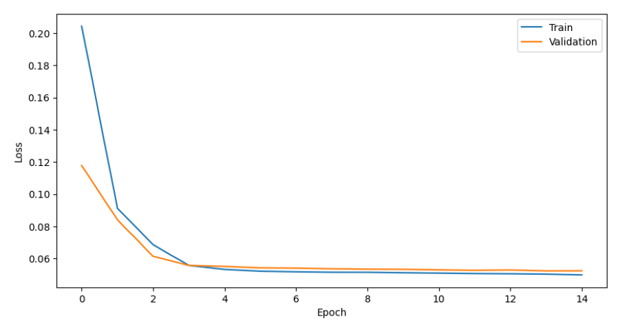

```
Training curve
<scaled size: (448 x 855) >
```

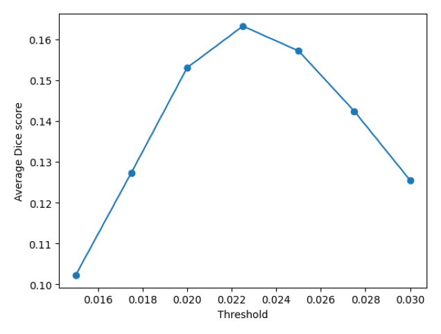

```
Average DICE score v.s. threshold
<scaled size: (432 x 576) >
```

```python
# Display the results of model convnet1 with conv layer 3*3
vd.dispmvx("convnet1_A3_train.png", size=1.5, capt="Training curve")
vd.dispmvx("convnet1_A3_th.png", size=1.5, capt="Average DICE score v.s. threshold")
```

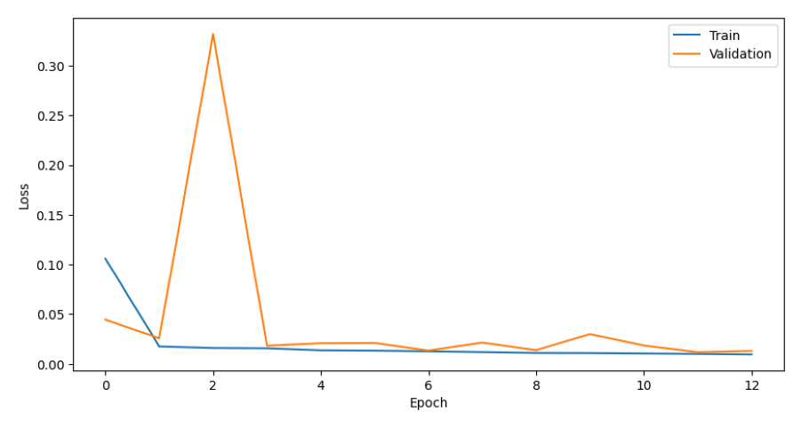

```
Training curve
<scaled size: (448 x 855) >
```

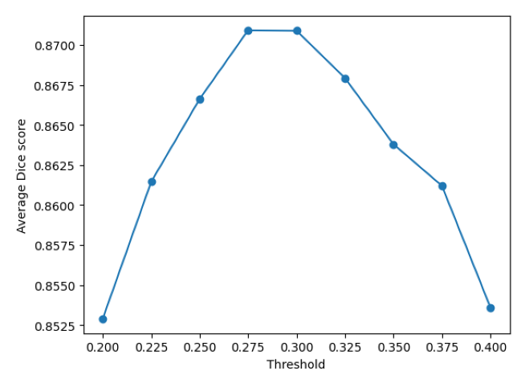

```
Average DICE score v.s. threshold
<scaled size: (432 x 593) >
```

```python
# Display the results of model unet2 with conv layer 3*3
vd.dispmvx("unet2_A3_train.png", size=1.5, capt="Training curve")
vd.dispmvx("unet2_A3_th.png", size=1.5, capt="Average DICE score v.s. threshold")
```

## A.4. Summary

### Comparison of approaches

[output not shown]

### Discusssion

#### 5. In some cases, the problem of over-fitting may occur due to large number of epochs or difficulty in convergence of models.

#### 6. The optimal threshold of all models is quite small (sometimes even less than 0.1), because the datasets are highly imbalanced. In the matching images, there are usually way more black pixels than white pixels.